# Report4

## Load the R packages

```r
library(knitr)
library(readr)
library(tidyverse)
library(dplyr)
library(tidyr)
library(stringr)
library(purrr)
library(httr)
library(tibble)
library(rvest)
library(xml2)
library(leaflet)
library(ggmap)
```

## Preparations: connect to the website and get the data for the necessary variables:

```r
page_html <- xml2::read_html("https://epfl-exts.github.io/rental-scrape/")
# location
location <- page_html %>%
  rvest::html_nodes("div.address") %>%
  html_text()
# price
price <- page_html %>%
  rvest::html_nodes("div.price span.float-right") %>%
  rvest::html_nodes("strong") %>%
  html_text()
# object_type
object_type <- page_html %>%
  rvest::html_nodes("div.object-type") %>%
  html_text()
# rooms
rooms <- page_html %>%
  rvest::html_nodes("div.rooms") %>%
  rvest::html_nodes("strong") %>%
  html_text()
# living_space
living_space <- page_html %>%
  rvest::html_nodes("div.living-space") %>%
  rvest::html_nodes("strong") %>%
  html_text()
# floor
floor <- page_html %>%
  rvest::html_nodes("div.floor") %>%
  rvest::html_nodes("strong") %>%
  html_text()
# availability
availability <- page_html %>%
  rvest::html_nodes("div.availability") %>%
  rvest::html_nodes("strong") %>%
  html_text()
# usable_surface
usable_surface <- page_html %>%
  rvest::html_nodes("div.usable-surface") %>%
  rvest::html_nodes("strong") %>%
  html_text()
```

## Part 1

Build a dummy tibble:

```r
# location,price,currency,object_type,rooms,living_space,floor,availability,usable_surface
data <- dplyr::bind_cols(location=location,price=price,currency = price,rooms=rooms,living_space=living_space,floor=floor, availability=availability,usable_surface=usable_surface)
```

Now refine and correct it:

```r
data[(data=="Price on Request")]= NA
data <- data %>%
  mutate(currency = "CHF") %>%
  mutate(price = as.numeric(price)) %>%
  mutate(rooms = as.numeric(rooms))

living_space <- pull(data,living_space)
living_space_new <- str_remove(living_space, " m2")

data <- data %>%
  mutate(living_space = as.numeric(living_space_new))
```

## Part 2

Create a scatterplot showing how price evolves with living space of the flat:

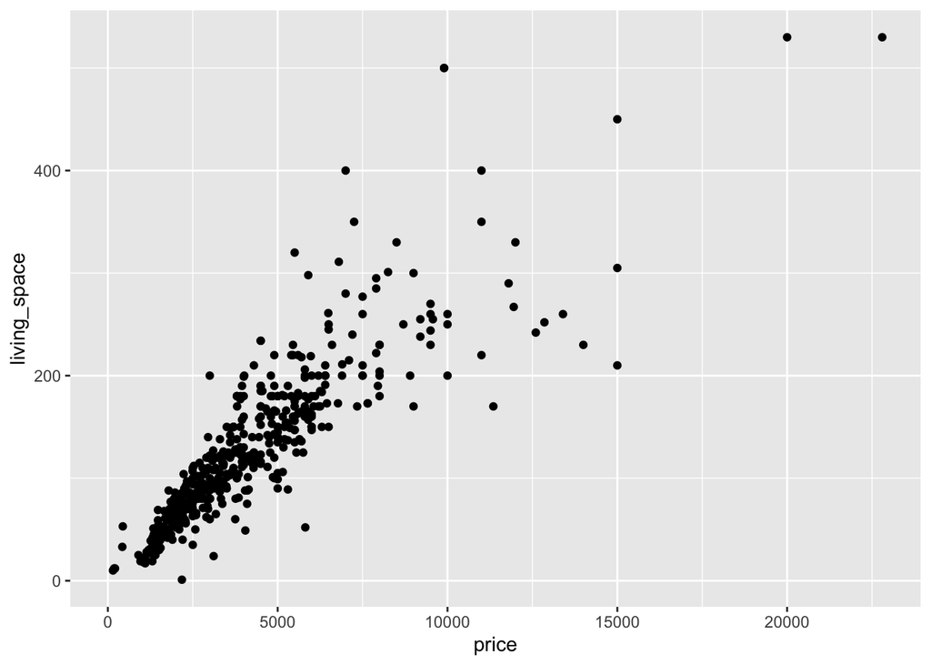

```r
ggplot(data, aes(x=price, y=living_space)) +
  geom_point()
```

## Part 3

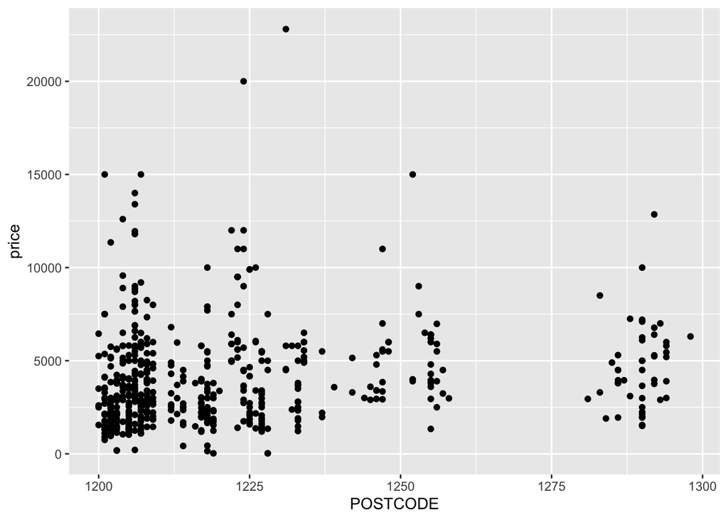

```r
first_split <- data.frame(do.call('rbind',strsplit(as.character(data$location),',',fixed=TRUE)))
second_split <- data.frame(do.call('rbind',strsplit(as.character(first_split$X2),' ',fixed=TRUE))) %>% as_tibble()
postcode <- pull(second_split,X2)
postcode[postcode=="quai"] = NA
postcode[postcode=="Vessy"] = NA
postcode[postcode=="avenue"] = NA
postcode[postcode=="chemin"] = NA
postcode[postcode=="route"] = NA
postcode[postcode=="rue"] = NA
postcode <- as.numeric(as.character(postcode))
data <- data %>%
  mutate(POSTCODE = postcode)
ggplot(data, aes(x=POSTCODE, y=price)) +
  geom_point()
```

Indeed, it seems that the agency is more active in the center (between the postcodes 1200 to 1225).

## Part 4

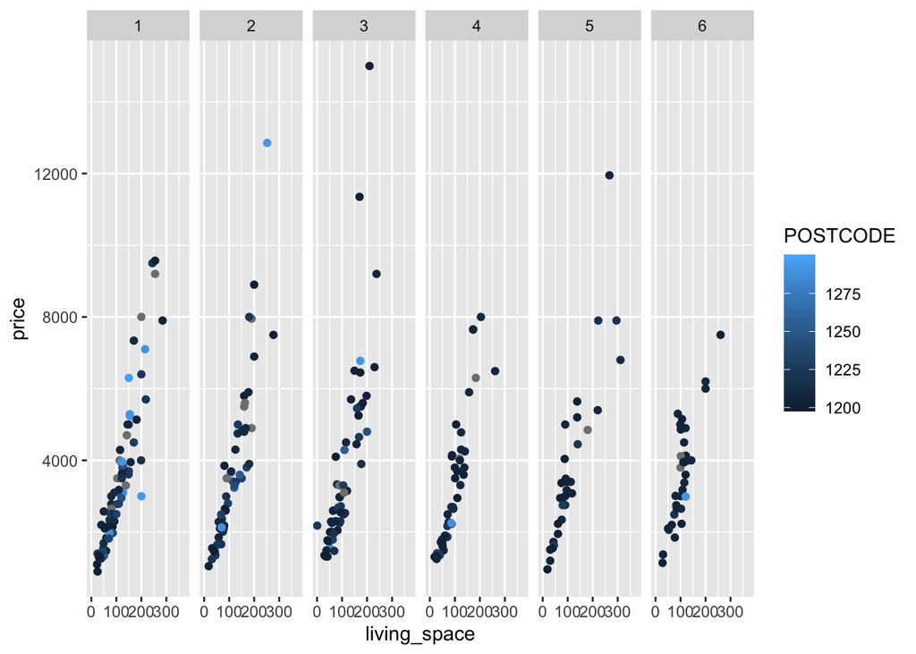

```r
data_temp <- data
data_temp[data_temp=="Underground"] = NA
data_temp <- data_temp %>%
  mutate(floor = as.numeric(floor))

data_temp %>%
  filter(floor<7) %>%
  ggplot(aes(x=living_space, y=price, color=POSTCODE)) +
  geom_point() +
  facet_grid(cols = vars(floor))
```

There is actually no clear message from this plot - only that the price correlates significantly with living space independently of the floor.

## Part 5

Do some data manipulation:

```r
# Retrieve the necessary information from the location column
rm(first_split,second_split)
first_split <- data.frame(do.call('rbind',strsplit(as.character(data$location),',',fixed=TRUE)))
second_split <- data.frame(do.call('rbind',strsplit(as.character(first_split$X1),' ',fixed=TRUE))) %>% as_tibble()
meta_information <- pull(second_split,X6)
# Write the meta information in a new column of the data tibble
data <- data %>%
  mutate(ADDRESS_META = meta_information)
```

Create two groups: only with addresses only available on demand and the rest:

```r
data_part5 <- data %>%
  select(price, living_space, floor, ADDRESS_META)
# Use the meta_information column to distinguish between "request-addresses" and "regular-addresses"
data_help <- pull(data_part5,ADDRESS_META)
data_help[data_help!="request"] = "regular"
data_part5 <- data %>%
  mutate(ADDRESS_META = data_help)
```

Figure to check if “request-addresses” are more expensive (which indeed they are on average) - note that the label “NA” refers to all those flats where the address is actually given on the website (this is just for simplicity - it could be labelled differently and more intuitively of course):

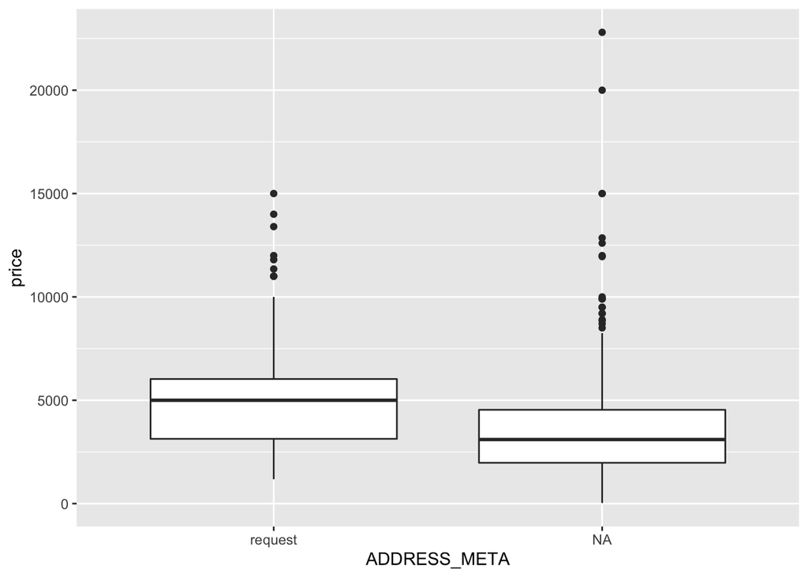

```r
data_part5 %>%
  ggplot(aes(x=ADDRESS_META, y=price)) +
  geom_boxplot()
```

Figure to check if “request-addresses” have bigger living space (which indeed they have on average):

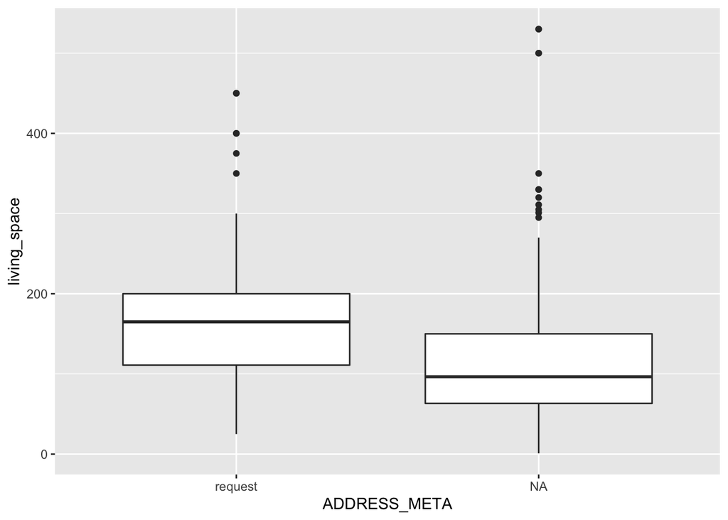

```r
data_part5 %>%
  ggplot(aes(x=ADDRESS_META, y=living_space)) +
  geom_boxplot()
```

Figure to check if “request-addresses” are generally located on a higher floor (the plot indicates that this is on first order not true - they’re about equally distributed):

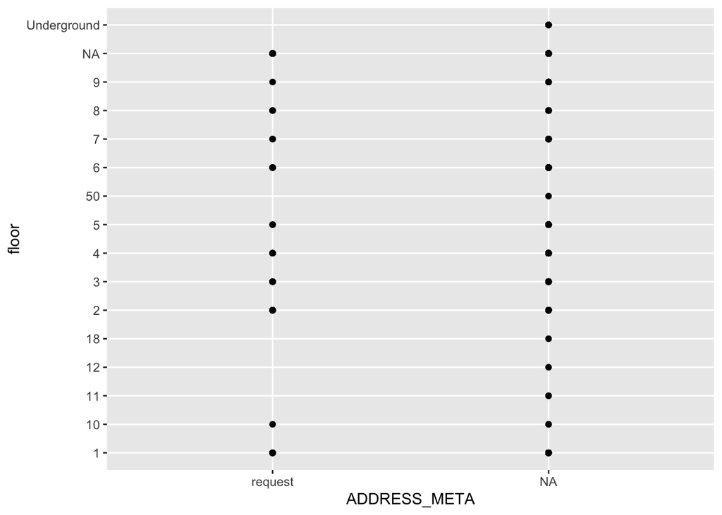

```r
data_part5 %>%
  ggplot(aes(x=ADDRESS_META, y=floor)) +
  geom_point()
```

```r
#Rue de la Terrassière 58, 1207 Genève  = lat 46.199 long 6.160
#Rue Liotard 46, 1202 Genève            = lat 46.211 long 6.130
#Avenue Henri-Golay 36, 1219 Châtelaine = lat 46.207 long 6.110
```

```r
m <- leaflet() %>%
  addTiles() %>%
  addMarkers(lat=46.199, lng=6.160, popup="Price 1900 CHF, 3.0 Rooms") %>%
  addMarkers(lat=46.211, lng=6.130, popup="Price 2100 CHF, 4.0 Rooms") %>%
  addMarkers(lat=46.207, lng=6.110, popup="Price 2340   CHF, 4.0 Rooms")
m  # Print the map
```

[interactive chart not shown]